# Relationship of Flight Origin Location with Number of Flights and Average Distance

## by Austin Dowd

## Investigation Overview

In this investigation I wanted to look at the relationship geographic location of airports and originating flights had with the number of flights originating at each location and the average distance for flights originating at those locations

## Dataset Overview

The data consists of a millions of flights of certified U.S. air carriers that account for at least one percent of domestic scheduled passenger revenues over a ten year span from 1998-2007 as well as information on airports across the United States and its territories. Flight data of interest includes flight numbers, originating airport and flight distance. Aiport data includes location information for each airport attributed by a unique code that includes city and state location as well as longitude and latitude coordinates.

## Flight Traffic by State ordered by location

In examining traffic out of each airport, count of flights originating at each airport, location of airports by state does not present any clear shape or evidence of distribution pattern when ordered East to West, or North to South

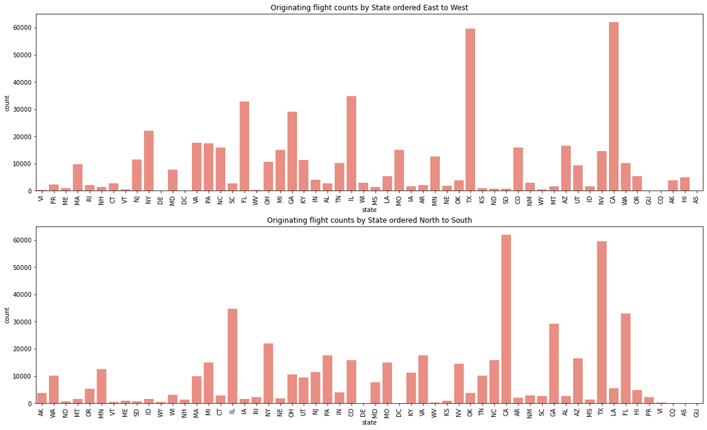

## Distribution of Flight Distance

Flight distance between airports can vary, with some flights traveling short distances, to neighboring states, to longer flights from one coast to another. The flight distances from each airport can tell quite a bit about what type of traffic an airport typically manages, whether its flights within a particular area of the country, like a flight from JFK (New York City, N) to DCA (Washington DC) which is only 213 miles, or a Flight to a neighboring area of the country, like a flight from JFK to ATL (Atlanta, GA) which is 760 miles, or a cross country flight, like JFK to LAX (Los Angeles, CA) is 2,475 miles.

A plot of flight distance across this dataset shows a right skewed distribution, with the largest count of flight distancecs between 250 and 500 miles, and a tapering off to between 2,500 and 3,000 miles.

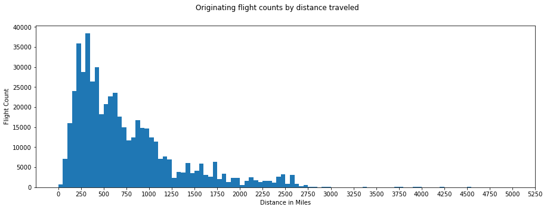

## Distribution of Average Flight Distance per Airport

Seeing that flight distance can be an indicator for areas of travel from an originating airport to its destination airport, an average of flight distances for flights originiating in each airport can help illustrate how far typical flights from each airport travel.

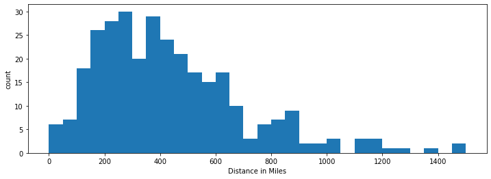

## Airport Geographic Density

Using the data available in the airport data frame, a plot of the longtitude and latitude variables for each airport code shows the density of airport coverage across the geographic regions covered in this data set.

Seeing as the largest cluster of points exists in the geographic coordinates for the Continental United States, a plot with axis limits to just those data allows for a more in depth analysis of just those airports. For that purpose, the remaining investigation will focus on those airports only

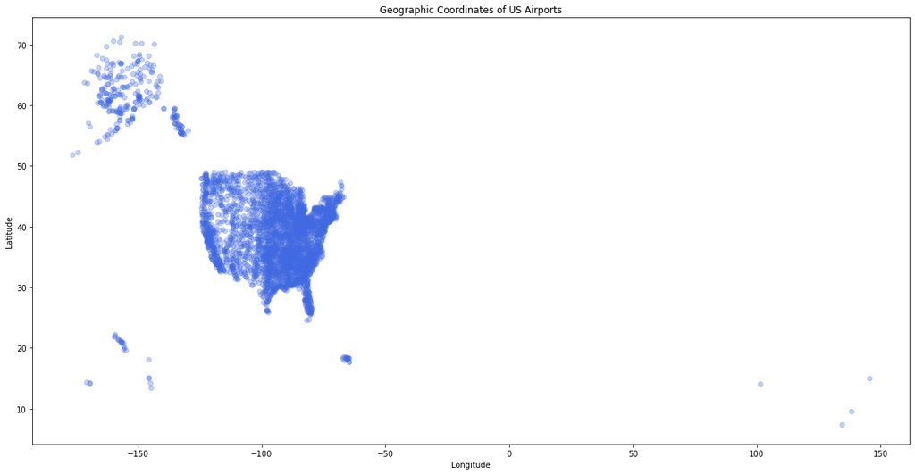

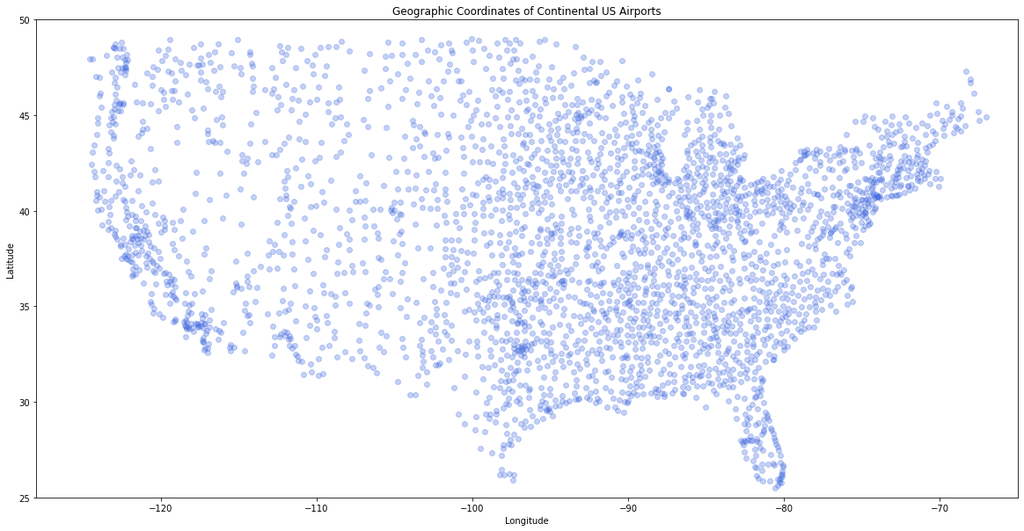

## Heatmap of Airport Density by Longitude and Latitude

A more accurate representation of airport location density is seen in this heatmap plot of airport longitude (West to East) and latitude (South to North) variables with color mapping for counts of airport in each bin.

A few key observations here is the high count of airports located in certain areas of the plot. Particularly; in the North East, -75 to -70 on the x-axis and 37 to 45 on the y-axis; along the West Coast, -128 to -118 on the x-axis, and the low density of airports throughout the US Midwest, -110 and -100 on the x-axis.

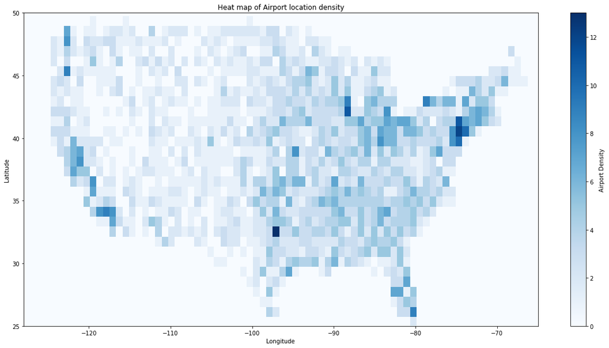

## Distance Traveled for flights from the 10 busiest airports

Since distance traveled can indicate the areas of the country flights are traveling to once leaving their originating airports, a box plot and violin plot of the 10 busiest airports by originating flight counts shows a non-uniform distribution of flight distances by each of these top 10 airports.

A few particular findings of particular note is the large range of flight distances for LAX and LAS when compared to ATL, DTW and DEN.

LAX also has a disporportionate number of flights exceeding 2,000 miles in comparison to other top 10 aiports

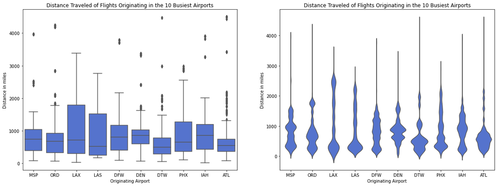

## Top 10 airport locations in comparison to others

Being that flight distances can indicate the typical flight traffic from an airport, and the large difference in distribution of flight distances for the top 10 airports, a plot of airport longitude and latitude with the top 10 airports highlighted and labeled can provide a bit more reasoning for this difference in distribution amongst the top 10 airports.

Most apparent is the location of LAX on the plot, which had the widest distribution of flight distances, and the largest amount of flights exceeding 2000 miles. It is located at the edge of location points, with next to no airports South and West of it (less then its x-axis longitude point and y axis latitude point).

Another take-away is DEN's location in the plot, which appears to be in an area of low airport density, and far removed from other top 10 airports. ATL is the only other airport that appears to not be closely neighbored by another top 10 airport.

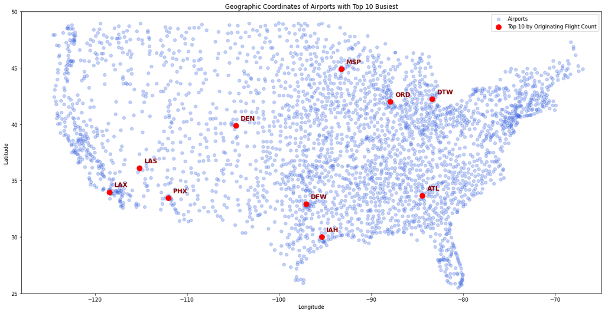

## Airport Density Heatmap with Top 10 airports highlighted

A density heatmap of airport locations further confirms the observations of the preceding location scatterplot and also provides a few other insights.

DEN is in fact in the midst of a low density area. ORD and DFW however appear to share longitude and latitude points consistent with some of the highest airport density locations in the plot outside of the Northeast region.

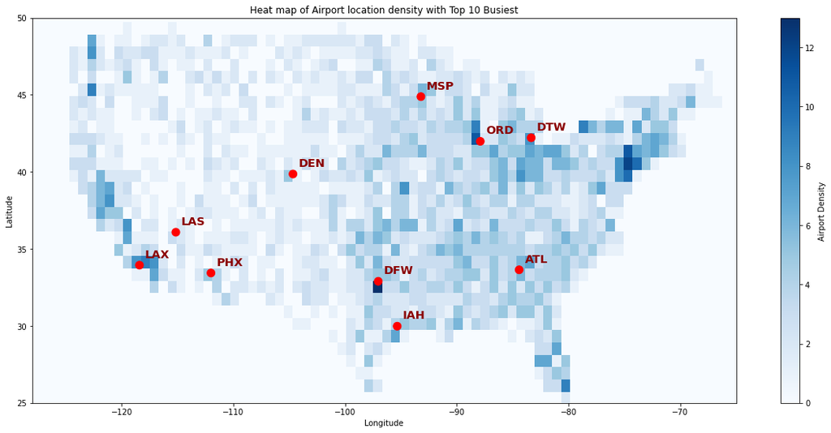

## Total flight count by Longitude and Latitude, with Top 10 airports highlighted

Flights originating in each location is of paricular interest for this analysis. As such, an examination of the counts of originating flights by geographic location, plotted using longitude and latitude variables, provides some additional insights.

First, a significant amount of location points have 0 values for flight counts. This is due in part to the data only covering certified U.S. air carriers that account for at least one percent of domestic scheduled passenger revenues. It appears a significant number of airports do not handle air traffic relevant to this data set.

Second, despite the fact that the 10 highlighted airports are the airports with the highest number of originating flights, LAX is the only airport that shares longitude and latitude coordinates with the highest flight counts by geographic coordinates. DFW is the only other aiport that appears to be in a location with flight counts above the median. The remaining 8 airports appear to be in geographic areas that handle below the median of flight counts as compared to other geographic areas.

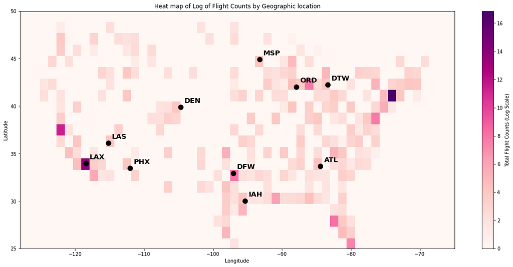

## Average Flight Distance per Airport by Longitude and Latitude

Plotting each airports locational coordinates with color mapping for its average flight distance provides some final insights into airport locations and its relationship to its flight counts and average flight distance.

It is clear here the number of airports originating flights versus the overal data for airport locations; 314 with flight data vs the 3,376 total number of airports.

Also, the airports with the highest average flight distance appear only on the edges of the plot. This would suggest that they handle a higher number of long distance flights (>2,000) such as coast to coast flights.

The top 10 airports also appear to all have an average distance flight close to or higher than the median average distance for all other airports.

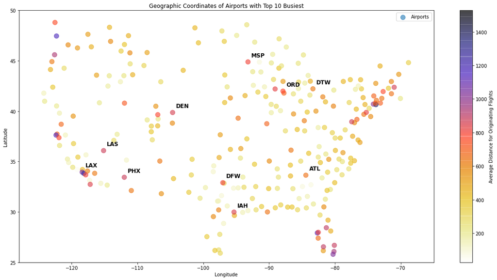